# Praktikum 6 Anreg

# Library

```r
library(readxl) # untuk membaca data
library(GGally) # untuk menghasilkan matriks hubungan antarpeubah
library(corrplot) # untuk menghasilkan matriks korelasi
library(dplyr) # untuk manipulasi data
library(car) # untuk memeriksa multikolinearitas
library(stargazer) # untuk menampilkan hasil perbandingan regresi
library(lmtest) # untuk uji kehomogenan ragam sisaan dan saling bebas
library(olsrr) # untuk pemeriksaan amatan tidak biasa
```

Data

```r
dt <- read_xlsx("/Users/intanaisa/Documents/Kuliah/Semester 4/Analisis Regresi/Dataset Anreg.xlsx")
dt
```

```
## # A tibble: 34 × 7
##    Provinsi   Jumlah Pengunjung (Y…¹ `Jumlah Tenaga Kerja` `Jumlah Objek Wisata`
##    <chr>                       <dbl>                 <dbl>                 <dbl>
##  1 Papua Bar…                  62780                   141                    15
##  2 Kepulauan…                1866681                   785                    52
##  3 Maluku                     308482                   110                    17
##  4 Sulawesi …                 535517                   345                    31
##  5 Sulawesi …                4517360                  1178                    90
##  6 Kepulauan…                2151799                   739                    56
##  7 Sulawesi …                 305198                   282                    29
##  8 Bengkulu                  1020904                   539                    41
##  9 Kalimanta…                1107930                   810                    66
## 10 Jawa Timur               55995143                 12820                   667
## # ℹ 24 more rows
## # ℹ abbreviated name: ¹`Jumlah Pengunjung (Y)`
## # ℹ 3 more variables: `Total Pengeluaran` <dbl>, `Tindak Pidana Korupsi` <dbl>,
## #   `Usaha Akomodasi` <dbl>
```

```r
str(dt) # menampilkan tipe data setiap peubah
```

```
## tibble [34 × 7] (S3: tbl_df/tbl/data.frame)
##  $ Provinsi             : chr [1:34] "Papua Barat" "Kepulauan Riau" "Maluku" "Sulawesi Tengah" ...
##  $ Jumlah Pengunjung (Y): num [1:34] 62780 1866681 308482 535517 4517360 ...
##  $ Jumlah Tenaga Kerja  : num [1:34] 141 785 110 345 1178 ...
##  $ Jumlah Objek Wisata  : num [1:34] 15 52 17 31 90 56 29 41 66 667 ...
##  $ Total Pengeluaran    : num [1:34] 1.04e+10 6.16e+10 2.38e+09 1.06e+10 7.00e+10 ...
##  $ Tindak Pidana Korupsi: num [1:34] 6085 5294 4512 9623 39443 ...
##  $ Usaha Akomodasi      : num [1:34] 98 421 363 691 1067 ...
```

```r
summary(dt) # menampilkan ringkasan data
```

```
##    Provinsi         Jumlah Pengunjung (Y) Jumlah Tenaga Kerja
##  Length:34          Min.   :   62780      Min.   :  105.0
##  Class :character   1st Qu.:  775612      1st Qu.:  355.5
##  Mode  :character   Median : 1922122      Median :  778.0
##                     Mean   :10170910      Mean   : 2282.5
##                     3rd Qu.: 4870902      3rd Qu.: 1529.2
##                     Max.   :73426352      Max.   :13336.0
##  Jumlah Objek Wisata Total Pengeluaran   Tindak Pidana Korupsi Usaha Akomodasi
##  Min.   : 13.00      Min.   :2.377e+09   Min.   : 1593         Min.   :  98.0
##  1st Qu.: 31.75      1st Qu.:1.215e+10   1st Qu.: 5477         1st Qu.: 295.5
##  Median : 55.00      Median :3.079e+10   Median : 8608         Median : 527.0
##  Mean   :134.03      Mean   :1.482e+11   Mean   :16529         Mean   : 907.7
##  3rd Qu.:126.00      3rd Qu.:9.219e+10   3rd Qu.:15667         3rd Qu.:1063.2
##  Max.   :712.00      Max.   :1.151e+12   Max.   :77261         Max.   :4154.0
```

```r
dt <- select(dt, -Provinsi)

library(dplyr)

dt <- dt %>%
  rename(
    Y = `Jumlah Pengunjung (Y)`,
    X1 = `Jumlah Tenaga Kerja`,
    X2 = `Jumlah Objek Wisata`,
    X3 = `Total Pengeluaran`,
    X4 = `Tindak Pidana Korupsi`,
    X5 = `Usaha Akomodasi`
  )
```

# Eksplorasi Data

## Peubah Respon

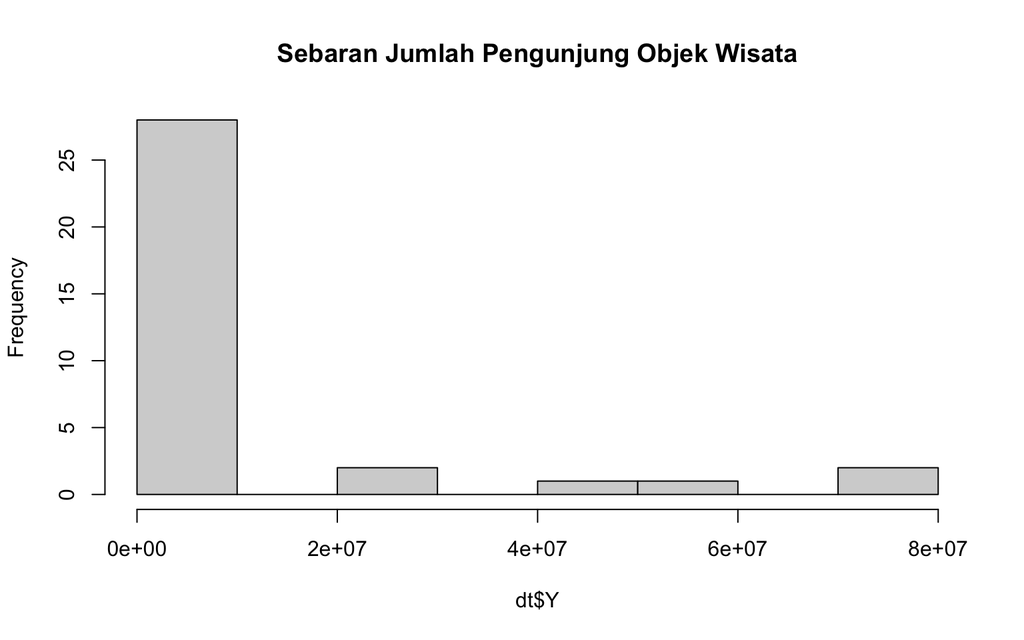

```r
hist(dt$Y, main = "Sebaran Jumlah Pengunjung Objek Wisata")
```

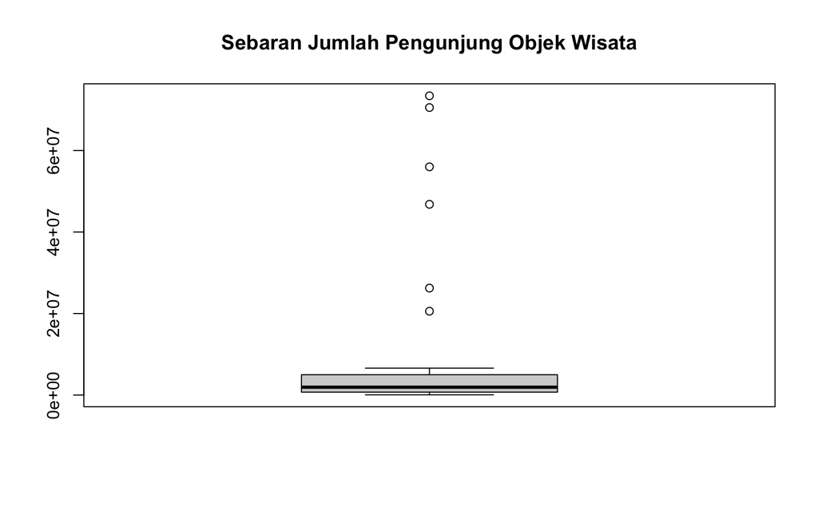

```r
boxplot(dt$Y, main = "Sebaran Jumlah Pengunjung Objek Wisata")
```

## Peubah Pennjelas vs Peubah Respon

### X1

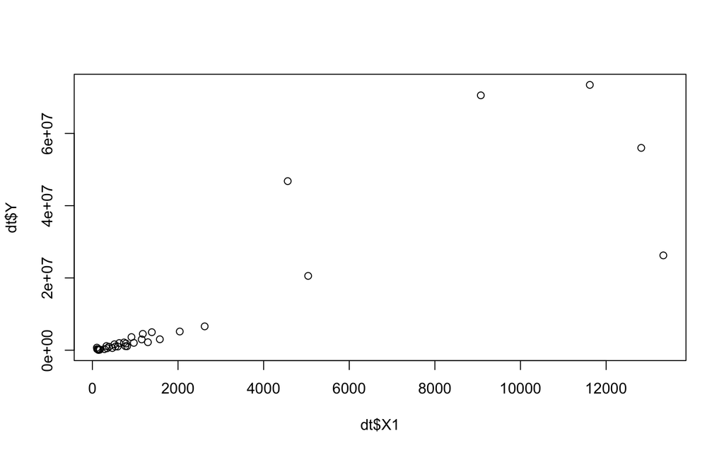

```r
plot(dt$X1, dt$Y)
```

Hubungan antara peubah X1 dan Y cenderung linear positif.

### X2

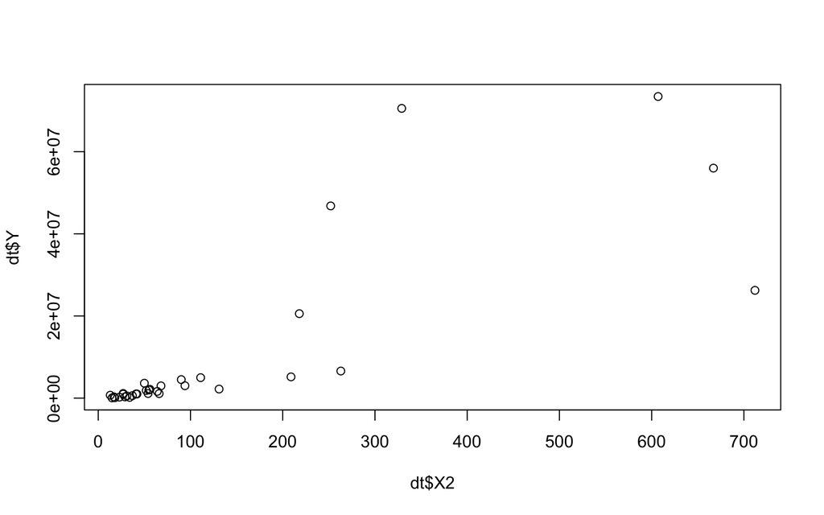

```r
plot(dt$X2, dt$Y)
```

### X3

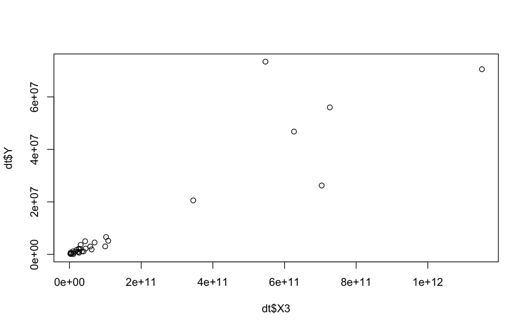

```r
plot(dt$X3, dt$Y)
```

Hubungan linearitas tampak antara peubah X3 dan Y, namun pada kuartil atas terlihat beberapa amatan X3 cenderung lebih menyebar terhadap Y.

### X4

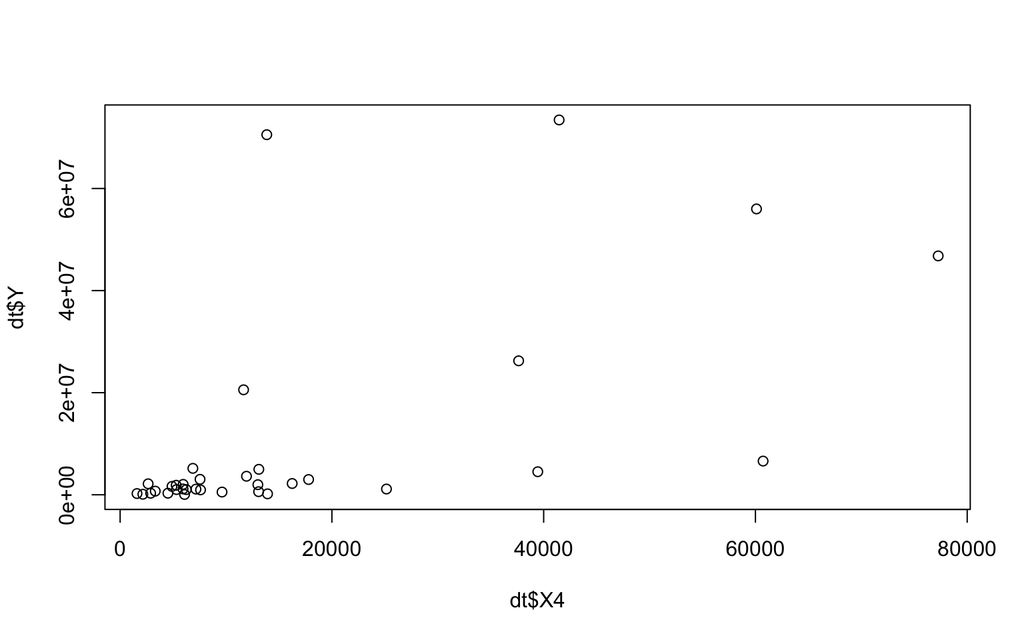

```r
plot(dt$X4, dt$Y)
```

Hubungan antara peubah X4 dan Y cenderung tidak linear.

# X5

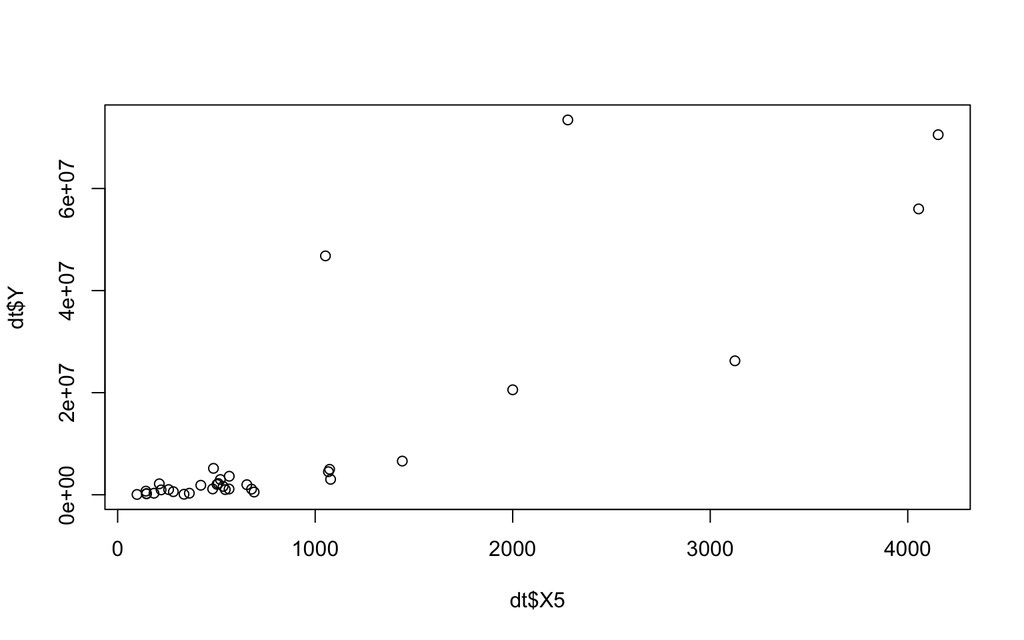

```r
plot(dt$X5, dt$Y)
```

Hubungan antara peubah X5 dan Y cenderung tidak linear.

## Korelasi

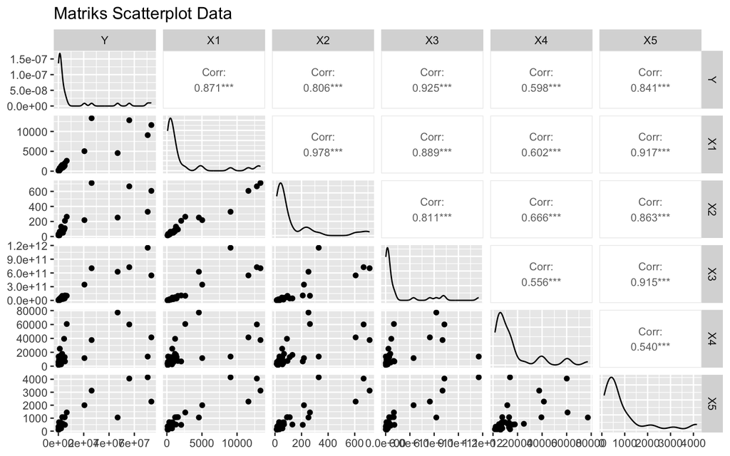

```r
ggpairs(dt,
        upper = list(continuous = wrap('cor', size = 3)),
        title = "Matriks Scatterplot Data")
```

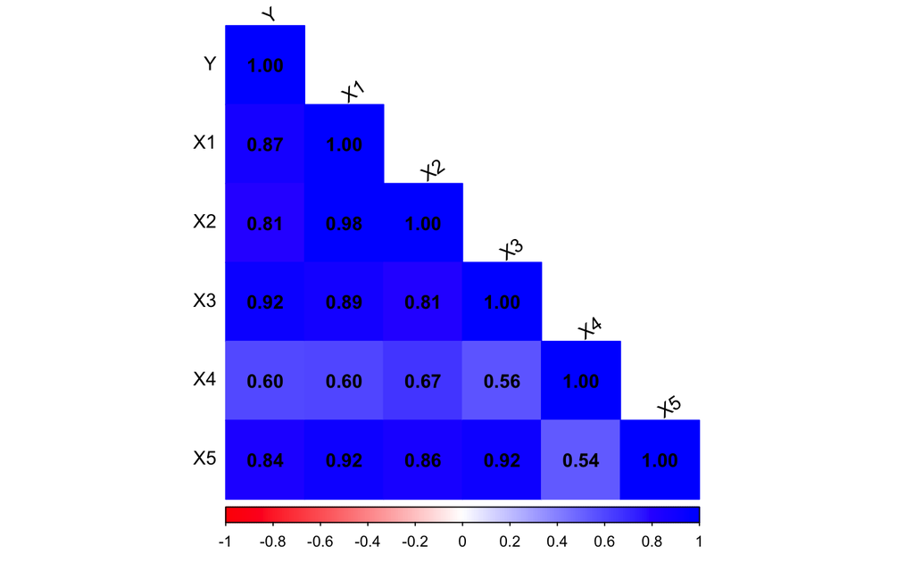

```r
cor_matrix <- cor(dt, use = "complete.obs")

corrplot(cor_matrix, method = "color", type = "lower",
         col = colorRampPalette(c("red", "white", "blue"))(200),
         addCoef.col = "black", tl.col = "black", tl.srt = 35)
```

Berdasarkan visualisasi korelogram, nilai koefisien korelasi Pearson antara variabel respon ($Y$) dengan seluruh variabel prediktor ($X_1, X_2, X_3, X_4, X_5$) menunjukkan hubungan linear positif. Seluruh nilai korelasi bernilai positif (berwarna biru), yang berarti jika variabel prediktor meningkat, maka jumlah pengunjung ($Y$) juga cenderung meningkat.

**Korelasi Antara Variabel Respon ($Y$) dengan Variabel Prediktor**

- $Y$ dengan $X_3$ (Total Pengeluaran): Memiliki hubungan linear positif yang paling kuat dengan nilai korelasi sebesar 0.92. Hal ini menunjukkan bahwa total pengeluaran memiliki pengaruh linear searah yang sangat dominan terhadap jumlah pengunjung.
- $Y$ dengan $X_1$ (Jumlah Tenaga Kerja) & $X_5$ (Usaha Akomodasi): Memiliki hubungan linear positif yang sangat kuat, masing-masing sebesar 0.87 dan 0.84.
- $Y$ dengan $X_2$ (Jumlah Objek Wisata): Memiliki hubungan linear positif yang kuat sebesar 0.81.
- $Y$ dengan $X_4$ (Tindak Pidana Korupsi): Memiliki hubungan linear positif yang paling lemah/moderat di antara variabel lainnya, yaitu sebesar 0.60.

**IIndikasi Multikolinieritas**

Berdasarkan matriks korelasi, ditemukan indikasi kuat terjadinya multikolinieritas tinggi (hubungan linear antar variabel bebas) pada model ini. Hal ini dibuktikan dengan adanya korelasi yang sangat kuat di antara sesama variabel prediktor ($X$), antara lain:

- $X_1$ (Jumlah Tenaga Kerja) dengan $X_2$ (Jumlah Objek Wisata): Korelasi sebesar 0.98 (Sangat Kuat).
- $X_1$ (Jumlah Tenaga Kerja) dengan $X_5$ (Usaha Akomodasi): Korelasi sebesar 0.92 (Sangat Kuat).
- $X_3$ (Total Pengeluaran) dengan $X_5$ (Usaha Akomodasi): Korelasi sebesar 0.92 (Sangat Kuat).

# Pemodelan

```r
model1 = lm(formula = Y ~ ., data = dt)
summary(model1)
```

```
##
## Call:
## lm(formula = Y ~ ., data = dt)
##
## Residuals:
##       Min        1Q    Median        3Q       Max
## -26194086  -1733906    -58459   1059371  25133038
##
## Coefficients:
##               Estimate Std. Error t value Pr(>|t|)
## (Intercept)  1.241e+06  2.201e+06   0.564   0.5773
## X1           6.967e+03  3.368e+03   2.068   0.0480 *
## X2          -8.943e+04  5.515e+04  -1.622   0.1161
## X3           4.467e-05  1.591e-05   2.807   0.0090 **
## X4           2.051e+02  1.107e+02   1.853   0.0744 .
## X5          -5.503e+03  3.687e+03  -1.493   0.1467
## ---
## Signif. codes:  0 '***' 0.001 '**' 0.01 '*' 0.05 '.' 0.1 ' ' 1
##
## Residual standard error: 7285000 on 28 degrees of freedom
## Multiple R-squared:  0.8896, Adjusted R-squared:  0.8699
## F-statistic: 45.14 on 5 and 28 DF,  p-value: 1.512e-12
```

Persamaan yang terbentuk adalah
$$\hat{Y}
= 1240974.70509 + 6966.61471X_1 - 89432.93528X_2 + 0.00004X_3 +
205.09028X_4 - 5502.54246X_5$$

Pada ringkasan model ini dapat dilihat bahwa secara simultan minimal ada satu peubah penjelas yang berpengaruh signifikan terhadap Y. Hal tersebut selaras karena terdapat dugaan parameter yang signifikan pada taraf nyata 5%, yaitu peubah X1 dan X3.

# Pemeriksaan Multikolinearitas

## Perubahan Peubah

```r
mod1 <- lm(Y ~ ., dt[1:2])
mod2 <- lm(Y ~ ., dt[1:3])
mod3 <- lm(Y ~ ., dt[1:4])
mod4 <- lm(Y ~ ., dt[1:5])
mod5 <- lm(Y ~ ., dt)

stargazer(mod1, mod2, mod3, mod4, mod5,
          type = "text", single.row = TRUE)
```

```
##
## ======================================================================================================================================================================
##                                                                                    Dependent variable:
##                     --------------------------------------------------------------------------------------------------------------------------------------------------
##                                                                                             Y
##                                 (1)                           (2)                          (3)                          (4)                           (5)
## ----------------------------------------------------------------------------------------------------------------------------------------------------------------------
## X1                     4,738.569*** (472.906)      10,433.440*** (2,067.103)      2,242.379 (2,832.315)        5,728.931* (3,333.020)       6,966.615** (3,368.306)
## X2                                               -116,823.800*** (41,482.090)    -15,947.550 (44,513.170)     -81,718.630 (56,059.110)     -89,432.930 (55,151.620)
## X3                                                                                 0.00005*** (0.00001)         0.00004** (0.00002)          0.00004*** (0.00002)
## X4                                                                                                               205.839* (112.986)           205.090* (110.669)
## X5                                                                                                                                          -5,502.542 (3,686.691)
## Constant            -644,874.500 (2,038,691.000) 2,014,401.000 (2,075,553.000) -218,201.900 (1,854,942.000) -710,277.900 (1,807,451.000) 1,240,975.000 (2,200,755.000)
## ----------------------------------------------------------------------------------------------------------------------------------------------------------------------
## Observations                     34                           34                            34                           34                           34
## R2                             0.758                         0.808                        0.867                        0.881                         0.890
## Adjusted R2                    0.751                         0.795                        0.854                        0.864                         0.870
## Residual Std. Error   10,084,581.000 (df = 32)      9,142,894.000 (df = 31)      7,719,695.000 (df = 30)      7,437,588.000 (df = 29)       7,284,985.000 (df = 28)
## F Statistic           100.403*** (df = 1; 32)       65.041*** (df = 2; 31)        65.317*** (df = 3; 30)       53.604*** (df = 4; 29)       45.144*** (df = 5; 28)
## ======================================================================================================================================================================
## Note:                                                                                                                                      *p<0.1; **p<0.05; ***p<0.01
```

## Perubahan Banyak Data

```r
mod5_1 <- lm(Y ~ ., dt[1:15,])
stargazer(summary(mod5)$coefficients, summary(mod5_1)$coefficients,
          type = "text",
          font.size = "small")
```

```
##
## ===========================================================
##               Estimate     Std. Error   t value Pr(> | t| )
## -----------------------------------------------------------
## (Intercept) 1,240,975.000 2,200,755.000  0.564     0.577
## X1            6,966.615     3,368.306    2.068     0.048
## X2           -89,432.930   55,151.620   -1.622     0.116
## X3             0.00004       0.00002     2.807     0.009
## X4             205.090       110.669     1.853     0.074
## X5           -5,502.542     3,686.691   -1.493     0.147
## -----------------------------------------------------------
##
## ========================================================
##               Estimate   Std. Error  t value Pr(> | t| )
## --------------------------------------------------------
## (Intercept) -730,175.800 469,618.900 -1.555     0.154
## X1           9,235.906    2,429.236   3.802     0.004
## X2          -57,414.760  24,463.690  -2.347     0.044
## X3            -0.00003     0.00003   -1.351     0.210
## X4             47.257      37.656     1.255     0.241
## X5            -354.280    1,563.171  -0.227     0.826
## --------------------------------------------------------
```

## Akar Ciri

```r
x <- dt[-1]
r <- cor(x)
(ev <- eigen(r)$values)
```

```
## [1] 4.133892850 0.575849605 0.208573950 0.075644947 0.006038647
```

```r
# Simultan
if ((max(ev) / min(ev)) <= 100) {
  cat("Tidak ada multikolinearitas\n")
} else if ((max(ev) / min(ev)) > 100 & (max(ev) / min(ev)) <= 1000) {
  cat("Ada multikolinearitas yang lemah\n")
} else {
  cat("Ada multikolinearitas yang kuat\n")
}
```

```
## Ada multikolinearitas yang lemah
```

Rasio nilai eigen maksimum terhadap minimum (Condition Number) menghasilkan nilai sebesar $684.58$ (berada di rentang $100 < CN \le 1000$). Hal ini mengindikasikan adanya gejala multikolinieritas yang terdeteksi pada tingkat lemah hingga moderat secara simultan di dalam model.

```r
# Parsial
if (all((max(ev) / ev) <= 1000)) {
  cat("Tidak ada multikolinearitas\n")
} else {
  cat("Ada multikolinearitas pada peubah penjelas ke:", which((max(ev) / ev) > 1000), "\n")
}
```

```
## Tidak ada multikolinearitas
```

Melalui pengujian parsial dengan nilai ambang batas ketat ($CN > 1000$), secara komparatif sistem tidak mendeteksi adanya struktur multikolinieritas spesifik yang ekstrem pada peubah tertentu.

## Nilai VIF

```r
vif(model1)
```

```
##        X1        X2        X3        X4        X5
## 97.214621 64.718466 11.782103  2.687781  9.189623
```

Meskipun uji nilai eigen menunjukkan gejala yang lemah secara simultan, pemeriksaan lebih detail melalui nilai VIF menunjukkan indikasi multikolinieritas yang nyata dan kuat pada beberapa peubah independen. Peubah $X_1$ ($VIF = 97.214621$), $X_2$ ($VIF = 64.718466$), dan $X_3$ ($VIF = 11.782103$) memiliki nilai VIF yang jauh melebihi batas toleransi umum ($VIF > 10$). Sementara itu, peubah $X_4$ dan $X_5$ dinyatakan bebas dari multikolinieritas ($VIF < 10$). Penanganan dari permasalahan ini dilakukan dengan menghilangkan peubah dengan nilai VIF tertinggi, yaitu X1.

# Pemodelan Penyisihan Peubah

```r
model2 <- lm(Y ~ X2+X3+X4+X5, data = dt)
summary(model2)
```

```
##
## Call:
## lm(formula = Y ~ X2 + X3 + X4 + X5, data = dt)
##
## Residuals:
##       Min        1Q    Median        3Q       Max
## -26354638  -1435082    129813   1044589  30081653
##
## Coefficients:
##               Estimate Std. Error t value Pr(>|t|)
## (Intercept) -4.426e+05  2.157e+06  -0.205    0.839
## X2           2.011e+04  1.622e+04   1.240    0.225
## X3           6.694e-05  1.236e-05   5.415 8.01e-06 ***
## X4           7.796e+01  9.709e+01   0.803    0.429
## X5          -3.625e+03  3.770e+03  -0.962    0.344
## ---
## Signif. codes:  0 '***' 0.001 '**' 0.01 '*' 0.05 '.' 0.1 ' ' 1
##
## Residual standard error: 7686000 on 29 degrees of freedom
## Multiple R-squared:  0.8728, Adjusted R-squared:  0.8552
## F-statistic: 49.74 on 4 and 29 DF,  p-value: 1.417e-12
```

Persamaan yang terbentuk adalah

$$\hat{Y} = -442635.90181 + 20112.12045X_2
+ 0.00007X_3 + 77.96198X_4 - 3625.30829X_5$$

Pada ringkasan model ini dapat dilihat bahwa secara simultan minimal ada satu peubah penjelas yang berpengaruh signifikan terhadap $Y$ (karena nilai p-value pada F-statistic sebesar $0.000000000001417$ jauh lebih kecil dari taraf nyata 5%). Hal tersebut selaras karena terdapat dugaan parameter yang signifikan secara parsial pada taraf nyata 5%, yaitu peubah $X_3$ (dengan nilai p-value $0.00000801 < 0.05$). Sementara itu, peubah lainnya ($X_2, X_4,$ dan $X_5$) tidak berpengaruh signifikan secara parsial terhadap $Y$ pada taraf nyata tersebut.

## Nilai VIF

```r
vif(model2)
```

```
##       X2       X3       X4       X5
## 5.031902 6.388378 1.858687 8.632642
```

Model hasil reduksi peubah menunjukkan bahwa nilai VIF < 10 sehingga dinyatakan tidak terjadi multikolinearitas.

# Pengujian Asumsi

## Eksplorasi Grafik

### Plot Sisaan vs Y duga

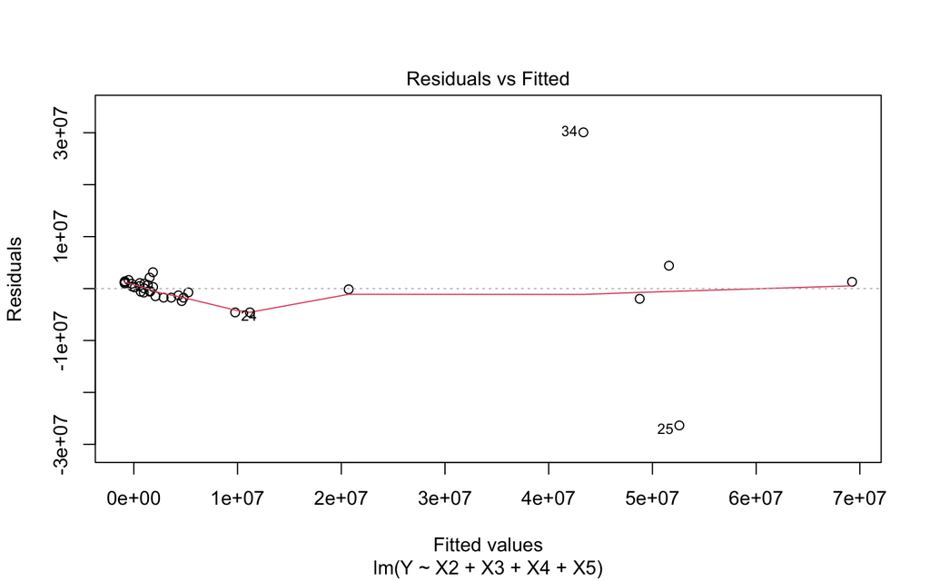

```r
plot(model2,1)
```

Berdasarkan grafik Residuals vs Fitted yang diperoleh dari hasil pemodelan lm(Y ~ X2 + X3 + X4 + X5), berikut adalah analisis terhadap asumsi kehomogenan ragam sisaan (homoskedastisitas) dan kelinieran model:

1. Uji Nilai Harapan Sisaan: Sisaan (residuals) terlihat menyebar di sekitar garis horizontal nol (0). Hal ini mengindikasikan bahwa nilai harapan (expected value) dari sisaan secara umum mendekati atau sama dengan nol, yang berarti asumsi kelinieran model terpenuhi secara rata-rata.
2. Pemeriksaan Kehomogenan Ragam (Homoskedastisitas): Lebar pita atau sebaran titik-titik sisaan terlihat tidak sama untuk setiap nilai dugaan (fitted values). Sebaran titik menumpuk rapat di area nilai dugaan kecil (sebelah kiri), namun melebar secara drastis pada nilai dugaan yang lebih besar (sebelah kanan).
3. Pola Sisaan: Pola plot sisaan ini cenderung membentuk pola melebar menyerupai corong atau kipas. Pola corong yang kentara ini mengonfirmasi adanya pelanggaran asumsi heteroskedastisitas, yang berarti ragam sisaan bersifat tidak homogen (heteroskedastisitas). Selain itu, terdapat beberapa titik data pencilan (outlier) yang posisinya sangat jauh dari pusat sebaran, seperti data ke-34 dan ke-25.

### Plot Sisaan vs Urutan

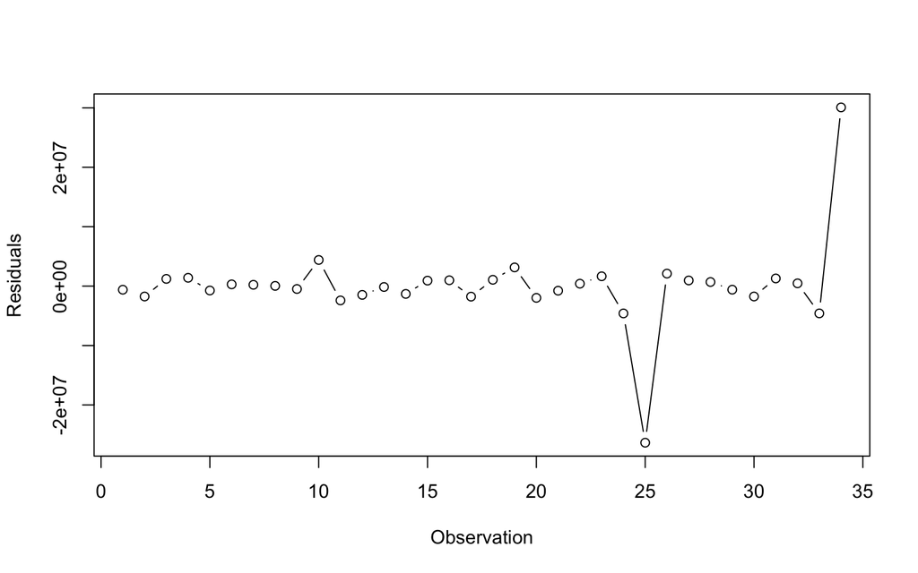

```r
plot(x = 1:dim(dt)[1],
     y = model2$residuals,
     type = 'b',
     ylab = "Residuals",
     xlab = "Observation")
```

Berdasarkan grafik Plot Sisaan vs Urutan, berikut adalah hasil analisis mengenai ada atau tidaknya ketergantungan antar-sisaan berdasarkan urutan waktu/data:

1. Pola Acak Sisaan: Secara umum, fluktuasi titik-titik sisaan dari pengamatan ke-1 hingga pengamatan ke-23 bergerak naik-turun secara acak di sekitar garis nol (0) tanpa membentuk pola gelombang (cyclical) atau tren linier yang konsisten. Hal ini menunjukkan tidak adanya indikasi autokorelasi yang kuat pada mayoritas runtun data.
2. Deteksi Data Ekstrem (Pencilan): Terdapat fluktuasi drastis yang sangat mencolok di akhir urutan pengamatan. Sisaan menukik tajam ke bawah pada pengamatan ke-25 dan melonjak sangat tinggi pada pengamatan ke-34.
3. Kesimpulan Asumsi: Meskipun terdapat lonjakan ekstrem pada data ke-25 dan ke-34 (yang bertindak sebagai outlier), secara keseluruhan sisaan tidak membentuk pola sistematis yang berulang. Oleh karena itu, asumsi bahwa sisaan bersifat saling bebas (tidak terjadi masalah autokorelasi yang serius) masih dapat terpenuhi secara tentatif, namun data pencilan tersebut perlu mendapat perhatian khusus karena berpotensi mengganggu stabilitas model.

### QQ plot

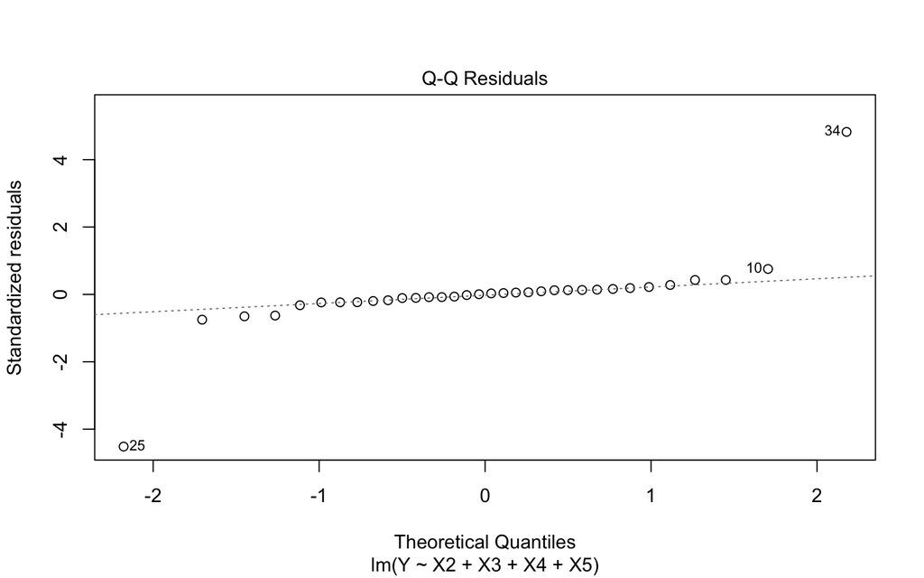

```r
plot(model2,2)
```

Berdasarkan grafik Q-Q Residuals, mayoritas sisaan sebenarnya sudah berdistribusi normal karena menempel rapat pada garis referensi di bagian tengah, namun keberadaan dua data pencilan ekstrem (data ke-25 dan ke-34) pada ujung ekor menyebabkan asumsi kenormalan sisaan secara keseluruhan menjadi terlanggar.

## Uji Formal

### Nilai harapan sisaan sama dengan nol

```r
t.test(model2$residuals,mu = 0,conf.level = 0.95)
```

```
##
##  One Sample t-test
##
## data:  model2$residuals
## t = 2.6602e-16, df = 33, p-value = 1
## alternative hypothesis: true mean is not equal to 0
## 95 percent confidence interval:
##  -2513884  2513884
## sample estimates:
##    mean of x
## 3.287021e-10
```

Nilai p pada uji t sama dengan 1 yang lebih besar dari alpha 5%, sehingga dinyatakan asumsi nilai harapan sisaan sama dengan nol terpenuhi

### Ragam sisaan homogen

```r
bptest(model2)
```

```
##
##  studentized Breusch-Pagan test
##
## data:  model2
## BP = 24.51, df = 4, p-value = 6.312e-05
```

Berdasarkan hasil uji Breusch-Pagan, diperoleh nilai $p\text{-value} = 0.00006312$. Karena nilai p-value jauh lebih kecil dari taraf nyata $5\%\ (0.00006312 < 0.05)$, maka tolak $H_0$ dan terima $H_1$. Hal ini menunjukkan bahwa ragam sisaan bersifat tidak konstan, sehingga asumsi ragam sisaan homogen tidak terpenuhi (terjadi masalah heteroskedastisitas).

### Sisaan saling bebas

```r
dwtest(model2)
```

```
##
##  Durbin-Watson test
##
## data:  model2
## DW = 1.5822, p-value = 0.1045
## alternative hypothesis: true autocorrelation is greater than 0
```

Nilai p pada uji durbin watson sama dengan 0.1045 yang lebih besar dari alpha 5%, sehingga dinyatakan asumsi sisaan saling bebas terpenuhi

### Normalitas Sisaan

```r
shapiro.test(model2$residuals)
```

```
##
##  Shapiro-Wilk normality test
##
## data:  model2$residuals
## W = 0.56472, p-value = 7.128e-09
```

Berdasarkan hasil uji Shapiro-Wilk, diperoleh nilai $p\text{-value} = 0.000000007128$. Karena nilai p-value jauh lebih kecil dari taraf nyata $5\%\ (0.000000007128 < 0.05)$, maka tolak $H_0$. Hal ini menunjukkan bahwa sisaan model tidak mengikuti distribusi normal, sehingga asumsi normalitas sisaan tidak terpenuhi.

# Pemeriksaan Amatan Tidak Biasa

```r
#fungsi
ri_stud <- rstudent(model2)
ri_stan <- rstandard(model2)
hii_fungsi <- hatvalues(model2)

#manual
X <- model.matrix(model2)
X_inv_xt <- X %*% solve(t(X) %*% X) %*% t(X)
```

[output not shown]

```r
hii_manual <- diag(X_inv_xt)
```

[output not shown]

```r
anova_model <- anova(model2)
s <- sqrt(anova_model["Residuals", "Mean Sq"])
ei <- model2$residuals
ri_manual <- ei/(s*sqrt(1-hii_manual))
```

[output not shown]

```r
nilai <- data.frame(ri_stud, ri_stan, ri_manual, hii_fungsi, hii_manual)
```

[output not shown]

```r
nilai
```

[output not shown]

## Pencilan

```r
for (i in 1:dim(nilai)[1]){
  absri <- abs(nilai[,2])
  pencilan <- which(absri > 2)
}
```

[output not shown]

```r
pencilan
```

[output not shown]

Matriks $X^TX$ yang singular berdampak pada matriks nilai yang tak dapat dibuat. Sehingga pengidentifikasian pencilan secara manual tak bisa dilakukan.

## Leverage

```r
n <- dim(dt)[1]
p <- length(model2$coefficients)

for (i in 1:dim(nilai)[1]){
  cutoff <- 2*p/n
  titik_leverage <- which(hii_fungsi > cutoff)
}
```

[output not shown]

```r
titik_leverage
```

[output not shown]

Matriks $X^TX$ yang singular berdampak pada matriks nilai yang tak dapat dibuat. Sehingga pengidentifikasian leverage secara manual tak bisa dilakukan.

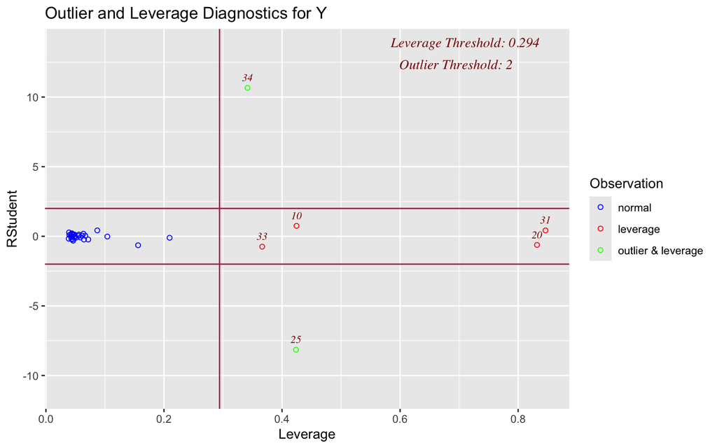

```r
ols_plot_resid_lev(model2)
```

Berdasarkan grafik diagnostik, sebagian besar amatan berada pada kondisi normal (warna biru). Namun, pengamatan ke-10, 20, 31, dan 33 terdeteksi sebagai leverage points karena memiliki nilai ekstrem pada peubah penjelas (melebihi batas 0.294), sedangkan pengamatan ke-25 dan 34 teridentifikasi sebagai data pencilan sekaligus penumpil (outlier & leverage) yang paling berpengaruh ekstrem karena sisaan bakunya menembus batas $\pm 2$.

## Amatan Berpengaruh

### Jarak Cook

```r
di <- cooks.distance(model2)
f <- qf(0.05,p,n-p, lower.tail = F)
data.frame(di, di>f)
```

```
##              di di...f
## 1  8.253944e-05  FALSE
## 2  5.144237e-04  FALSE
## 3  2.417969e-04  FALSE
## 4  4.791983e-04  FALSE
## 5  6.211305e-04  FALSE
## 6  2.255611e-05  FALSE
## 7  1.029755e-05  FALSE
## 8  2.791489e-07  FALSE
## 9  3.751868e-05  FALSE
## 10 8.406862e-02  FALSE
## 11 9.965674e-04  FALSE
## 12 3.478594e-04  FALSE
## 13 9.584842e-06  FALSE
## 14 2.438761e-04  FALSE
```

[output cut: 20 more lines]

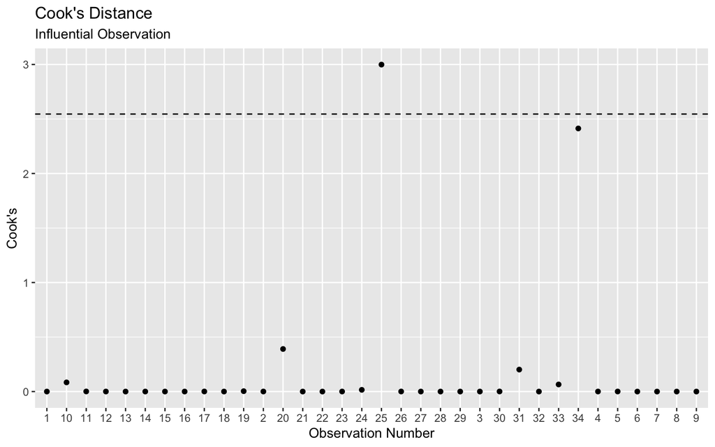

```r
cooks_crit = f
model_cooks <- cooks.distance(model2)
df <- data.frame(obs = names(model_cooks),
                 cooks = model_cooks)
ggplot(df, aes(y = cooks, x = obs)) +
  geom_point() +
  geom_hline(yintercept = cooks_crit, linetype="dashed") +
  labs(title = "Cook's Distance",
       subtitle = "Influential Observation ",
       x = "Observation Number",
       y = "Cook's")
```

### DFBETAS

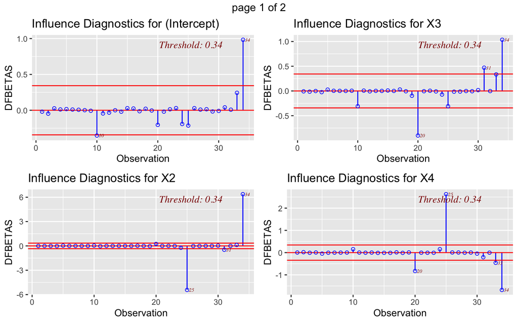

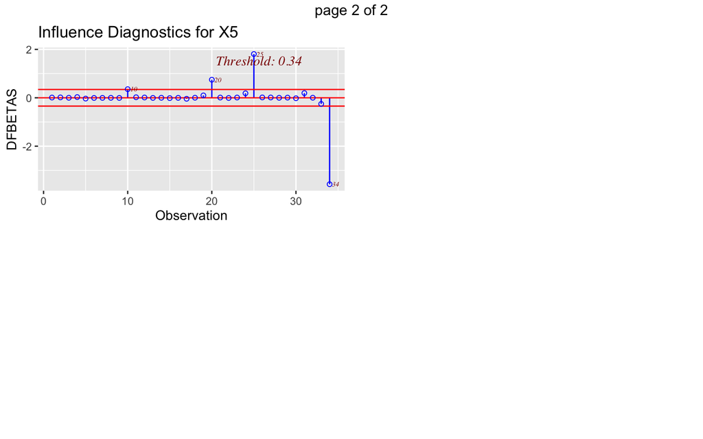

```r
ols_plot_dfbetas(model2)
```

Hasil DFBETAS akan menunjukkan pengaruh observasi terhadap setiap koefisien regresi, sehingga ada output untuk setiap parameter regresi. DFBETAS mengukur seberapa besar koefisien regresi berubah jika suatu observasi dihapus dari model.

### DFFITS

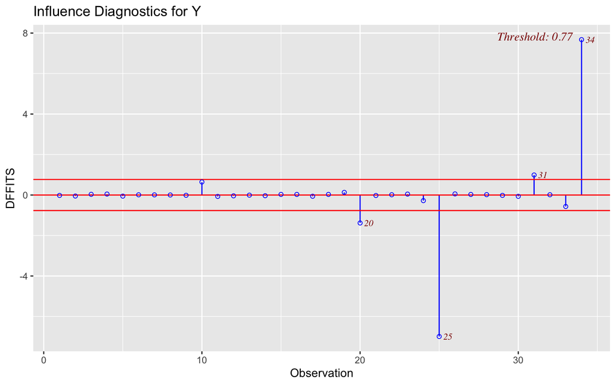

```r
ols_plot_dffits(model2)
```

Hasil DFFITS menunjukkan pengaruh observasi terhadap nilai prediksi Y, sehingga hanya menghasilkan satu output. DFFITS mengukur seberapa besar nilai prediksi $\hat{Y}_i$ berubah jika suatu observasi dihapus dari model, sehingga lebih tepat digunakan jika ingin melihat pengaruh observasi terhadap hasil model secara keseluruhan

```r
DFFITSi <- dffits(model2)

amatan_berpengaruh <- vector("list", dim(nilai)[1])
```

[output not shown]

```r
for (i in 1:dim(nilai)[1]) {
  cutoff <- 2 * sqrt((p / n))
  amatan_berpengaruh[[i]] <- which(abs(DFFITSi) > cutoff)
}
```

[output not shown]

```r
berpengaruh <- unlist(amatan_berpengaruh)
```

[output not shown]

```r
amatan_berpengaruh <- sort(unique(berpengaruh))
```

[output not shown]

```r
amatan_berpengaruh
```

[output not shown]

Matriks $X^TX$ yang singular berdampak pada matriks nilai yang tak dapat dibuat. Sehingga pengidentifikasian menggunakan DFFITS secara manual tidak dapat dilakukan.

# Pemodelan Penyisihan Amatan

```r
# gunakan peubah penjelas yang sudah diseleksi

dt1 <- dt %>% slice(-25)
model3 <- lm(Y ~ X2 + X3 + X4 + X5, dt1)

dt2 <- dt %>% slice(-34)
model4 <- lm(Y ~ X2 + X3 + X4 + X5, dt2)

dt3 <- dt %>% slice(-c(25, 34))
model5 <- lm(Y ~ X2 + X3 + X4 + X5, dt3)
```

```r
get_metrics <- function(model) {
  adj_r2 <- summary(model)$adj.r.squared
  sse <- sum(model$residuals^2)
  return(c(adj_r2, sse))
}

model_metrics <- data.frame(
  Model = c("Model 2", "Model 3", "Model 4", "Model 5"),
  Adjusted_R2 = sapply(list(model2, model3, model4, model5),
                       function(m) get_metrics(m)[1]),
  SSE = sapply(list(model2, model3, model4, model5),
               function(m) get_metrics(m)[2])
)

print(model_metrics)
```

```
##     Model Adjusted_R2          SSE
## 1 Model 2   0.8552345 1.713015e+15
## 2 Model 3   0.9560211 5.079221e+14
## 3 Model 4   0.9585595 3.387697e+14
## 4 Model 5   0.9892985 8.397002e+13
```

```r
stargazer(model2, model4, type = "text", font.size = "small",
          report = "vc*p")
```

```
##
## ===================================================================
##                                   Dependent variable:
##                     -----------------------------------------------
##                                            Y
##                               (1)                     (2)
## -------------------------------------------------------------------
## X2                        20,112.120            -26,706.970***
##                            p = 0.226               p = 0.005
##
## X3                         0.0001***               0.0001***
##                           p = 0.00001              p = 0.000
##
## X4                          77.962                151.736***
##                            p = 0.429               p = 0.002
##
## X5                        -3,625.308               2,467.917
##                            p = 0.345               p = 0.182
##
## Constant                 -442,635.900           -1,402,832.000
##                            p = 0.839               p = 0.164
##
## -------------------------------------------------------------------
## Observations                  34                      33
## R2                           0.873                   0.964
## Adjusted R2                  0.855                   0.959
## Residual Std. Error 7,685,668.000 (df = 29) 3,478,350.000 (df = 28)
## F Statistic         49.739*** (df = 4; 29)  186.048*** (df = 4; 28)
## ===================================================================
## Note:                                   *p<0.1; **p<0.05; ***p<0.01
```